# Take_Home_Final_Sai_Giridhar

Sai Giridhar Rao Allada

12/16/2021

# Q1

```r
IPLpoints <- read.csv("IPLpoints.csv")
IPLpoints2 <- read.csv("IPLpoints2.csv")
names(IPLpoints)[1]<-'Year'
IPL14 <- subset(IPLpoints, Year %in% c(2008:2011, 2014:2021))
p.win<-676/1372
```

## a

```r
expected<-98 * dbinom(0:14, 14, p.win)

actual_expected<-c(sum(expected[1:5]))
actual_expected<-c(actual_expected,expected[6:10])
actual_expected<-c(actual_expected,sum(expected[11:15]))
cat("Expected wins for each category:",actual_expected)
```

```
## Expected wins for each category: 9.70368 12.67504 18.46622 20.4978 17.42019 11.27974 7.957334
```

```r
cat("\nVerifying if the Sum of all wins is 98:",sum(actual_expected))
```

```
##
## Verifying if the Sum of all wins is 98: 98
```

## b

```r
possiblewins<-c(0,1,2,3,4,5,6,7,8,9,10,11,12,13,14)
observed<-c()
for (w in possiblewins){
  observed<-c(observed,sum(IPL14$Wins == w))
  #cat("\n Observed wins if total wins is ",w,":",sum(IPL14$Wins == w))
}
actual_observed<-c(sum(observed[1:5]))
actual_observed<-c(actual_observed,observed[6:10])
actual_observed<-c(actual_observed,sum(observed[11:15]))
cat("Observed wins for each category:",actual_observed)
```

```
## Observed wins for each category: 12 8 18 24 13 16 7
```

## c

```r
actual_observed
```

```
## [1] 12  8 18 24 13 16  7
```

```r
X2 <- sum((actual_observed - actual_expected)^2 / actual_expected)
cat("Pearson's Chi Squared statistic:", X2)
```

```
## Pearson's Chi Squared statistic: 6.089939
```

```r
cat("P-Value:",1 - pchisq(X2, df=6))
```

```
## P-Value: 0.4131909
```

## d

The IPL is not completely random as there are strong teams and weak teams. The large pvalue confirms the null hypothesis but does not prove that the game is completely random. Some teams tend to perform better tha others.

# Q2

```r
library(ggplot2)
temp=IPLpoints[IPLpoints$NZCoach==1,]
temp
```

```
##     Year Team NZCoach Wins Losses NoResult Points AdjPoints
## 1   2021  CSK       1    9      5        0     18    18.000
## 3   2021  KKR       1    7      7        0     14    14.000
## 6   2021  RCB       1    9      5        0     18    18.000
## 9   2020  CSK       1    6      8        0     12    12.000
## 11  2020  KKR       1    7      7        0     14    14.000
## 17  2019  CSK       1    9      5        0     18    18.000
## 25  2018  CSK       1    9      5        0     18    18.000
## 30  2018  RCB       1    6      8        0     12    12.000
## 38  2017  RCB       1    3     10        1      7     7.000
## 39  2017  RPS       1    9      5        0     18    18.000
## 46  2016  RCB       1    8      6        0     16    16.000
## 47  2016  RPS       1    5      9        0     10    10.000
## 49  2015  CSK       1    9      5        0     18    18.000
## 54  2015  RCB       1    7      5        2     16    16.000
## 57  2014  CSK       1    9      5        0     18    18.000
## 60  2014   MI       1    7      7        0     14    14.000
## 62  2014  RCB       1    5      9        0     10    10.000
## 65  2013  CSK       1   11      5        0     22    19.250
## 68  2013   MI       1   11      5        0     22    19.250
## 74  2012  CSK       1    8      7        1     17    14.875
## 83  2011  CSK       1    9      5        0     18    18.000
## 93  2010  CSK       1    7      7        0     14    14.000
## 101 2009  CSK       1    8      5        1     17    17.000
```

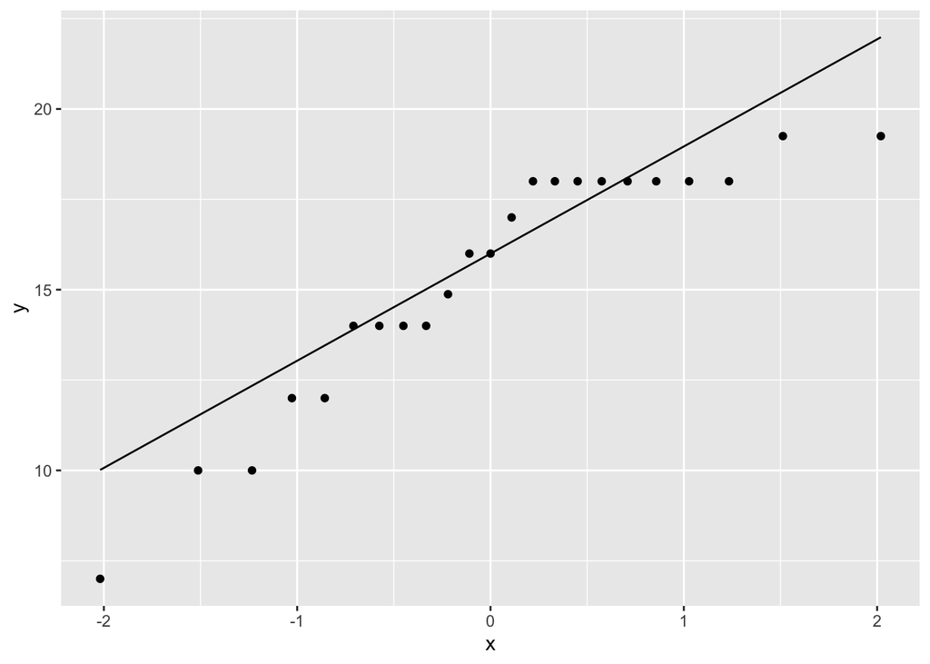

```r
ggplot(temp, aes(sample = temp$AdjPoints)) + stat_qq() + stat_qq_line()
```

The points are not perfectly normal as seen in the above plot but are good enough to go ahead with hypothesis test.

```r
t.test(temp$AdjPoints,mu=14,alternative = "greater")
```

```
##
##  One Sample t-test
##
## data:  temp$AdjPoints
## t = 1.9521, df = 22, p-value = 0.03188
## alternative hypothesis: true mean is greater than 14
## 95 percent confidence interval:
##  14.16419      Inf
## sample estimates:
## mean of x
##  15.36413
```

We perform a right tailed t-test to confirm our hypothesis that the Expected value of AdjPoints with a New Zealender coach to be greater than 14 hence why we consider the the null hypothesis to be less than or equal to 14. A low P-value of 0.03188 now proves that we can reject the null hypothesis. 95 % confidence interval of $\mu$ is [14.1619,Inf].